# Classification Supervisée

# CART ——————————————————————————

```r
arbre=rpart(RainTomorrow~.,data.train)
```

```r
cp.opt <- arbre$cptable[which.min(arbre$cptable[, "xerror"]), "CP"]
arbre.opt <- prune(arbre,cp=cp.opt)
print(arbre.opt)
```

```
## n= 1840
##
## node), split, n, loss, yval, (yprob)
##       * denotes terminal node
##
## 1) root 1840 587 No (0.6809783 0.3190217)
##   2) Humidity3pm< 81.5 1560 366 No (0.7653846 0.2346154) *
##   3) Humidity3pm>=81.5 280  59 Yes (0.2107143 0.7892857) *
```

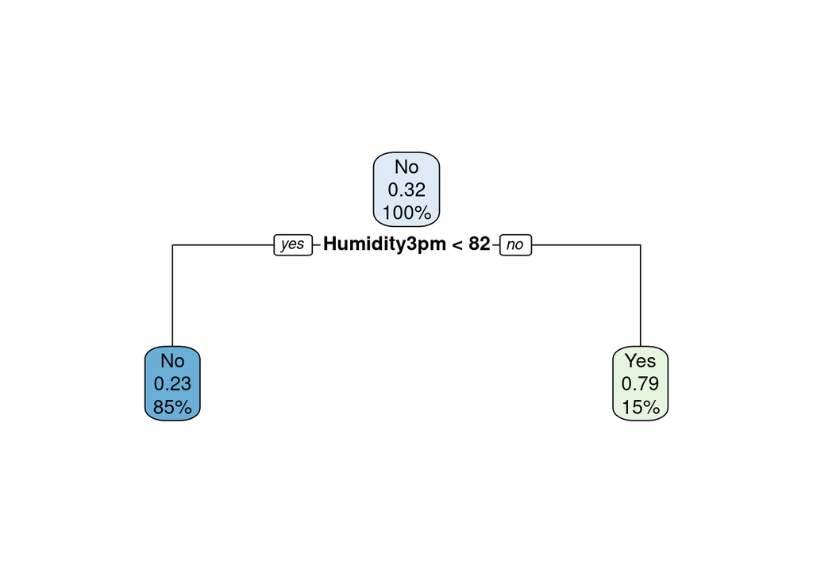

```r
rpart.plot(arbre.opt)
```

```r
pred_cart = predict(arbre.opt, newdata = data.test, type="class")
table(data.test$RainTomorrow, pred_cart)
```

```
##      pred_cart
##        No Yes
##   No  298  20
##   Yes  99  43
```

```r
accuracy_cart = mean(pred_cart == data.test$RainTomorrow)
accuracy_cart
```

```
## [1] 0.7413043
```

```r
#proba a posteriori de succes (dans la deuxième colonne) :
pred_cart_prob <- predict(arbre.opt,newdata=data.test, type='prob')[,2]

ROC_cart <- roc(data.test$RainTomorrow, pred_cart_prob)
```

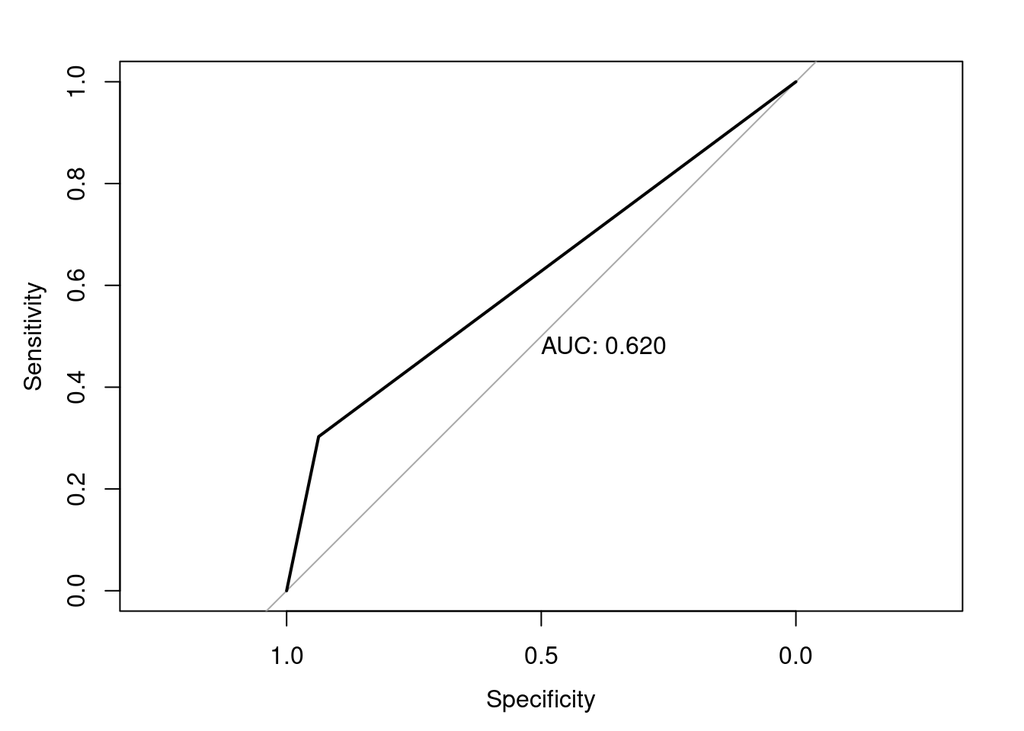

```r
plot(ROC_cart, print.auc=TRUE,  print.auc.y = 0.5) # Afficher l'aire sous la courbe ROC sur le graphique
```

```r
ROC_cart$auc # l'aire sous la courbe ROC
```

```
## Area under the curve: 0.62
```

# Random Forest ————————————————————————–

```r
fit_RF <-  randomForest(RainTomorrow~., data.train)
fit_RF
```

```
##
## Call:
##  randomForest(formula = RainTomorrow ~ ., data = data.train)
##                Type of random forest: classification
##                      Number of trees: 500
## No. of variables tried at each split: 3
##
##         OOB estimate of  error rate: 24.08%
## Confusion matrix:
##       No Yes class.error
## No  1124 129   0.1029529
## Yes  314 273   0.5349233
```

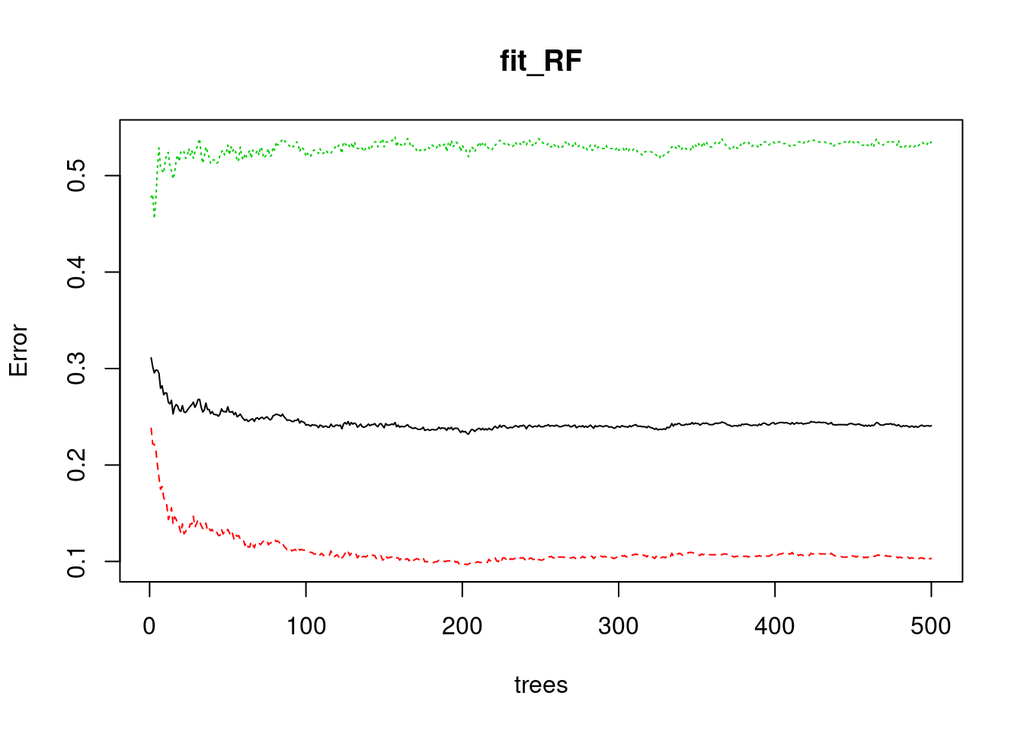

```r
plot(fit_RF)
```

Représentation de l’erreur Out of Bag : Les données non utilisées dans les échantillons boostrap sont utilisées pour estimer l’erreur de classification : Pour l’observation numéro i, on regarde les échantillons bootstrapés ne contenant pas cette observation. On construit un arbre pour chacun de ces échantillons, et on prédit la classe pour l’observation i avec cette forêt. Et on compare avec la vérité. En faisant ça pour chaque observation, on obtient l’erreur OOB.

En noire, erreur de classification totale, en rouge et verte les erreurs de classification pour les 2 classes : vert pour la class Yes et rouge pour la class No. L’erreur OOB pour la classe Yes est très élevée !

```r
table(data.test$RainTomorrow)
```

```
##
##  No Yes
## 318 142
```

```r
pred_rf = predict(fit_RF, newdata = data.test, type="class")
confusion = table(data.test$RainTomorrow, pred_rf)
confusion
```

```
##      pred_rf
##        No Yes
##   No  292  26
##   Yes  84  58
```

```r
accuracy_RF = mean(pred_rf == data.test$RainTomorrow)
accuracy_RF
```

```
## [1] 0.7608696
```

```r
err_RF = mean(pred_rf != data.test$RainTomorrow)
err_RF
```

```
## [1] 0.2391304
```

```r
# erreur class No :
confusion[1,2]/sum(confusion[1,])
```

```
## [1] 0.08176101
```

```r
# erreur class No :
confusion[2,1]/sum(confusion[2,])
```

```
## [1] 0.5915493
```

Globalement bonne accuracy ie peu d’erreurs mais beaucoup d’erreur pour classe Yes.

```r
#proba a posteriori de succes (dans la deuxième colonne) :
pred_rf_prob <- predict(fit_RF,newdata=data.test, type='prob')[,2]

ROC_rf <- roc(data.test$RainTomorrow, pred_rf_prob)
```

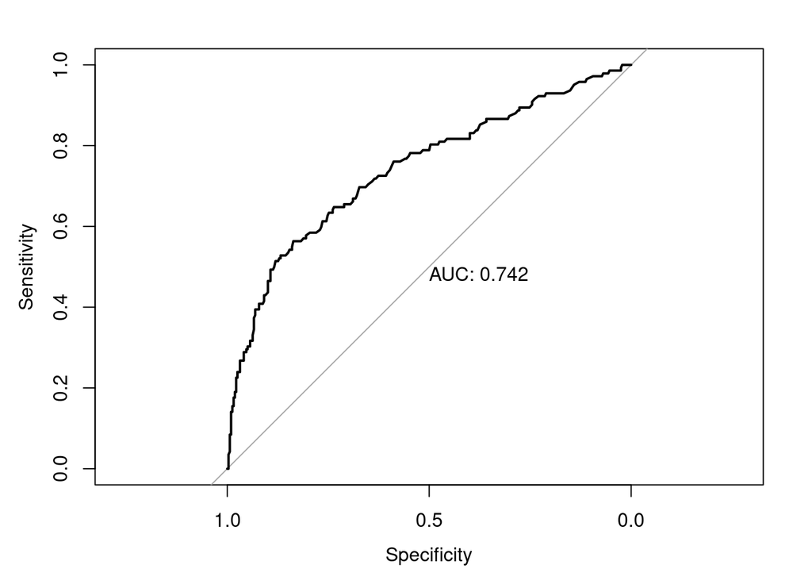

```r
plot(ROC_rf, print.auc=TRUE,  print.auc.y = 0.5) # Afficher l'aire sous la courbe ROC sur le graphique
```

```r
ROC_rf$auc # l'aire sous la courbe ROC
```

```
## Area under the curve: 0.7418
```

# Regression logistique ————————————————————–

```r
### Modèle
logit.train <- glm(RainTomorrow ~ ., family = binomial , data=data.train)
logit.train.AIC <- step(logit.train) #backward par defaut
```

```
## Start:  AIC=1736.12
## RainTomorrow ~ MinTemp + MaxTemp + Rainfall + Humidity9am + Humidity3pm +
##     Pressure9am + Pressure3pm + Temp9am + Temp3pm + RainToday
##
##               Df Deviance    AIC
## - Rainfall     1   1714.1 1734.1
## - MaxTemp      1   1714.2 1734.2
## - Humidity9am  1   1714.2 1734.2
## - Temp9am      1   1714.3 1734.3
## - Temp3pm      1   1714.5 1734.5
## - MinTemp      1   1714.6 1734.6
## <none>             1714.1 1736.1
## - RainToday    1   1721.4 1741.4
## - Humidity3pm  1   1779.2 1799.2
## - Pressure9am  1   1798.7 1818.7
## - Pressure3pm  1   1825.7 1845.7
##
## Step:  AIC=1734.12
## RainTomorrow ~ MinTemp + MaxTemp + Humidity9am + Humidity3pm +
##     Pressure9am + Pressure3pm + Temp9am + Temp3pm + RainToday
##
##               Df Deviance    AIC
## - MaxTemp      1   1714.2 1732.2
## - Humidity9am  1   1714.2 1732.2
## - Temp9am      1   1714.4 1732.4
## - Temp3pm      1   1714.5 1732.5
## - MinTemp      1   1714.6 1732.6
## <none>             1714.1 1734.1
## - RainToday    1   1722.0 1740.0
## - Humidity3pm  1   1779.2 1797.2
## - Pressure9am  1   1799.1 1817.1
## - Pressure3pm  1   1825.9 1843.9
##
## Step:  AIC=1732.16
## RainTomorrow ~ MinTemp + Humidity9am + Humidity3pm + Pressure9am +
##     Pressure3pm + Temp9am + Temp3pm + RainToday
##
##               Df Deviance    AIC
## - Humidity9am  1   1714.2 1730.2
## - Temp9am      1   1714.6 1730.6
```

[output cut: 31 more lines]

```
## - Pressure9am  1   1807.0 1819.0
## - Pressure3pm  1   1834.7 1846.7
## - Humidity3pm  1   1890.4 1902.4
##
## Step:  AIC=1728.26
## RainTomorrow ~ Humidity3pm + Pressure9am + Pressure3pm + Temp9am +
##     RainToday
##
##               Df Deviance    AIC
## <none>             1716.3 1728.3
## - RainToday    1   1723.8 1733.8
## - Temp9am      1   1755.8 1765.8
## - Pressure9am  1   1807.2 1817.2
## - Pressure3pm  1   1834.7 1844.7
## - Humidity3pm  1   1935.8 1945.8
```

# Prédiction

```r
pred_logit <- predict(logit.train.AIC, data.test, type="response")
class_logit <- ifelse(pred_logit >1/2, "Yes", "No")
```

#Table de confusion et accuracy

```r
table(data.test$RainTomorrow, class_logit)
```

```
##      class_logit
##        No Yes
##   No  284  34
##   Yes  74  68
```

```r
accuracy_logit = mean(class_logit == data.test$RainTomorrow)
accuracy_logit
```

```
## [1] 0.7652174
```

```r
err = mean(class_logit != data.test$RainTomorrow) # taux erreur total
paste('err=',err)
```

```
## [1] "err= 0.234782608695652"
```

```r
err_No = confusion['No','Yes']/sum(confusion['No',]) # taux erreur classe No
paste('err_No=',err_No)
```

```
## [1] "err_No= 0.0817610062893082"
```

```r
err_Yes = confusion['Yes', 'No']/sum(confusion['Yes',]) # taux erreur classe Yes
paste('err_Yes=',err_Yes)
```

```
## [1] "err_Yes= 0.591549295774648"
```

Meme probleme.

# On ré-équilibre le jeu d’apprentissage

```r
data.train.balanced <- SMOTE(RainTomorrow ~., as.data.frame(data.train))
table(data.train.balanced$RainTomorrow)
```

```
##
##   No  Yes
## 2348 1761
```

```r
fit_RF <- randomForest(RainTomorrow~.,data.train.balanced)
fit_RF
```

```
##
## Call:
##  randomForest(formula = RainTomorrow ~ ., data = data.train.balanced)
##                Type of random forest: classification
##                      Number of trees: 500
## No. of variables tried at each split: 3
##
##         OOB estimate of  error rate: 6.89%
## Confusion matrix:
##       No  Yes class.error
## No  2273   75  0.03194208
## Yes  208 1553  0.11811471
```

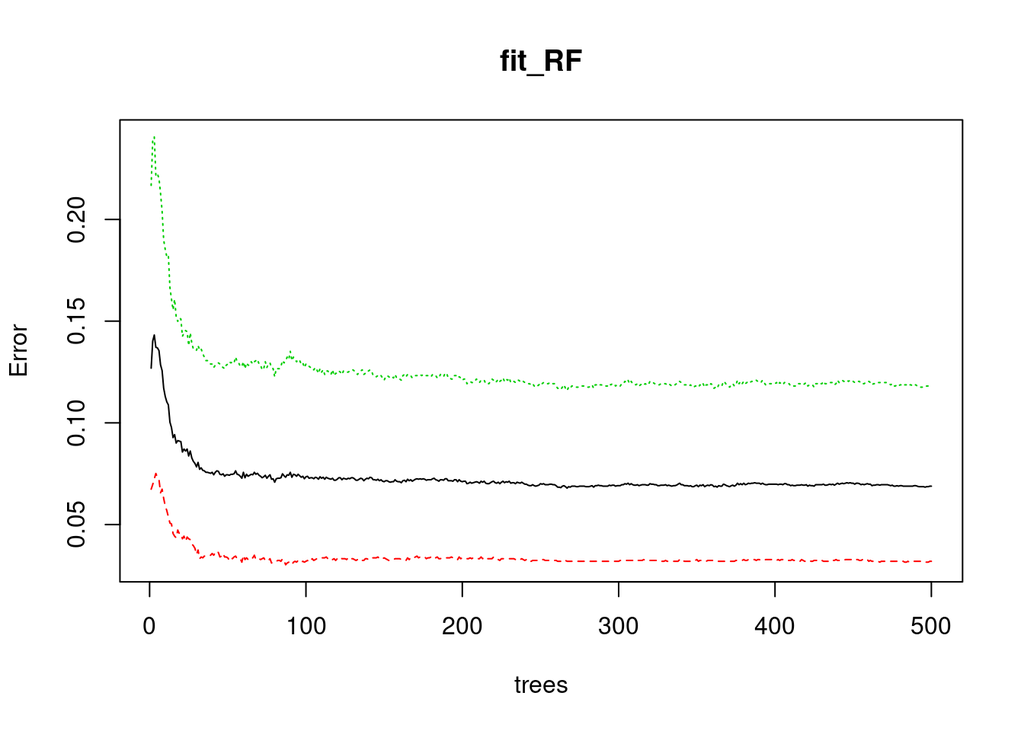

```r
plot(fit_RF)
```

```r
#Prédiction
class_RF= predict(fit_RF, newdata=data.test, type="response")
```

```r
#Table de confusion
confusion=table(class_RF, data.test$RainTomorrow)
confusion
```

```
##
## class_RF  No Yes
##      No  256  68
##      Yes  62  74
```

```r
table(data.test$RainTomorrow)
```

```
##
##  No Yes
## 318 142
```

```r
#Accuracy
accuracy_RF = mean(class_RF == data.test$RainTomorrow)
accuracy_RF
```

```
## [1] 0.7173913
```

```r
# erreur class No :
err_No = confusion['Yes', 'No']/sum(confusion[,'No']) # taux erreur classe No
paste('err_No=',err_No)
```

```
## [1] "err_No= 0.19496855345912"
```

```r
# erreur class Yes :
err_Yes = confusion['No','Yes']/sum(confusion[,'Yes']) # taux erreur classe Yes
paste('err_Yes=',err_Yes)
```

```
## [1] "err_Yes= 0.47887323943662"
```

Erreur Yes est diminué mais toujours élevé

# Régression logistique

```r
logit.train <- glm(RainTomorrow ~ ., family = binomial , data=data.train.balanced)
logit.train.AIC <- step(logit.train) #backward par defaut
```

```
## Start:  AIC=4091.45
## RainTomorrow ~ MinTemp + MaxTemp + Rainfall + Humidity9am + Humidity3pm +
##     Pressure9am + Pressure3pm + Temp9am + Temp3pm + RainToday
##
##               Df Deviance    AIC
## - Temp9am      1   4069.5 4089.5
## - MaxTemp      1   4069.6 4089.6
## <none>             4069.4 4091.4
## - Temp3pm      1   4071.5 4091.5
## - MinTemp      1   4071.5 4091.5
## - Rainfall     1   4075.3 4095.3
## - Humidity9am  1   4076.0 4096.0
## - RainToday    1   4143.4 4163.4
## - Humidity3pm  1   4198.8 4218.8
## - Pressure9am  1   4240.5 4260.5
## - Pressure3pm  1   4297.1 4317.1
##
## Step:  AIC=4089.45
## RainTomorrow ~ MinTemp + MaxTemp + Rainfall + Humidity9am + Humidity3pm +
##     Pressure9am + Pressure3pm + Temp3pm + RainToday
##
##               Df Deviance    AIC
## - MaxTemp      1   4069.6 4087.6
## <none>             4069.5 4089.5
## - Temp3pm      1   4071.7 4089.7
## - MinTemp      1   4071.9 4089.9
## - Rainfall     1   4075.3 4093.3
## - Humidity9am  1   4078.9 4096.9
## - RainToday    1   4143.5 4161.5
## - Humidity3pm  1   4235.5 4253.5
## - Pressure9am  1   4244.1 4262.1
## - Pressure3pm  1   4300.9 4318.9
##
## Step:  AIC=4087.63
## RainTomorrow ~ MinTemp + Rainfall + Humidity9am + Humidity3pm +
##     Pressure9am + Pressure3pm + Temp3pm + RainToday
##
##               Df Deviance    AIC
## <none>             4069.6 4087.6
## - MinTemp      1   4072.6 4088.6
## - Rainfall     1   4075.4 4091.4
## - Humidity9am  1   4081.3 4097.3
## - Temp3pm      1   4084.6 4100.6
## - RainToday    1   4144.2 4160.2
## - Pressure9am  1   4245.5 4261.5
## - Humidity3pm  1   4265.8 4281.8
## - Pressure3pm  1   4303.5 4319.5
```

```r
#Prédiction
pred_logit <- predict(logit.train.AIC, data.test, type="response")
class_logit <- ifelse(pred_logit >1/2, "Yes", "No")
```

```r
#Confusion
confusion = table(class_logit, data.test$RainTomorrow)
accuracy_logit = mean(class_logit == data.test$RainTomorrow)
accuracy_logit
```

```
## [1] 0.7543478
```

```r
mean(class_logit != data.test$RainTomorrow) # taux erreur total
```

```
## [1] 0.2456522
```

```r
paste('err=',err)
```

```
## [1] "err= 0.234782608695652"
```

```r
err_No = confusion['Yes', 'No']/sum(confusion[,'No']) # taux erreur classe No
paste('err_No=',err_No)
```

```
## [1] "err_No= 0.163522012578616"
```

```r
err_Yes = confusion['No','Yes']/sum(confusion[,'Yes']) # taux erreur classe Yes
paste('err_Yes=',err_Yes)
```

```
## [1] "err_Yes= 0.429577464788732"
```

```r
B=50
error= matrix(NA, nrow=B, ncol=6)
colnames(error)=c('RF total', 'logit total','RF No','logit No', 'logit Yes', 'RF Yes')
for (b in 1:B)
{
set.seed(b)
tr <- sample(1:n,n.test)
data.test <- data[tr,]
data.train <- data[-tr,]
data.train.balanced <- SMOTE(RainTomorrow ~., as.data.frame(data.train))
fit_RF <- randomForest(RainTomorrow~.,data.train.balanced)
class_RF= predict(fit_RF, newdata=data.test, type="response")
error[b,c(1,3,5)] = c(mean(class_RF != data.test$RainTomorrow), confusion['Yes', 'No']/sum(confusion[,'No']) ,
confusion['No','Yes']/sum(confusion[,'Yes']) )
logit.train <- glm(RainTomorrow ~ ., family = binomial , data=data.train.balanced)
logit.train.AIC <- step(logit.train) #backward par defaut
pred_logit <- predict(logit.train.AIC, data.test, type="response")
class_logit <- ifelse(pred_logit >1/2, "Yes", "No")
confusion = table(class_logit, data.test$RainTomorrow)
error[b,c(2,4,6)] = c(mean(class_logit!= data.test$RainTomorrow), confusion['Yes', 'No']/sum(confusion[,'No']) ,
confusion['No','Yes']/sum(confusion[,'Yes']) )
}
```

[output not shown]

[output cut: 2408 more lines]

[output not shown]

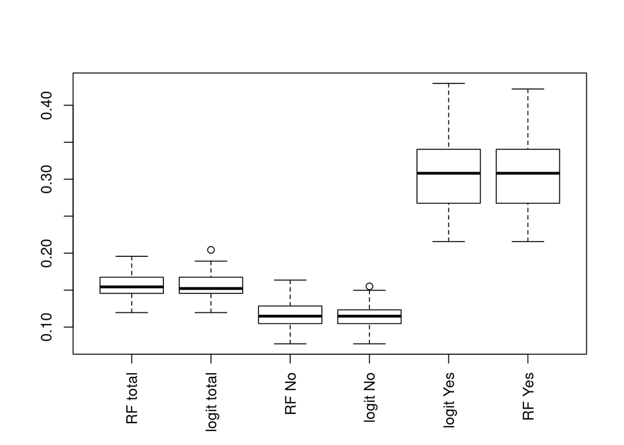

```r
boxplot(error, las=3)
```